# crosslink An R package for network visualization of grouped nodes

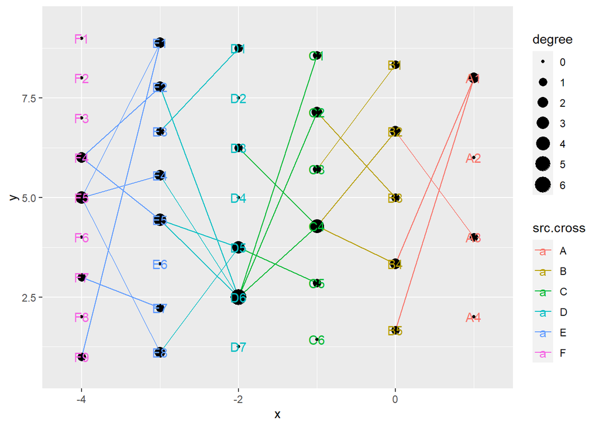

```r
# tf_flip, flip the figure according to x-axis or y-axis
cl %>% tf_flip(axis = "y") %>% cl_plot()
```

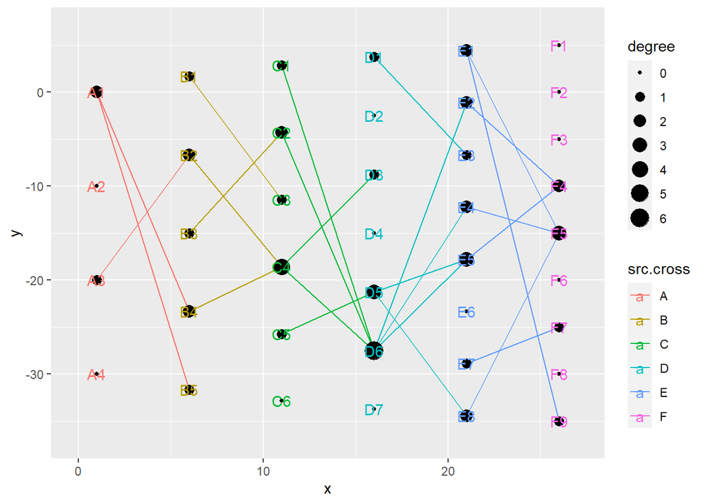

```r
# tf_scale
cl %>% tf_scale(x=0,y=1,scale = 5) %>% cl_plot()
```

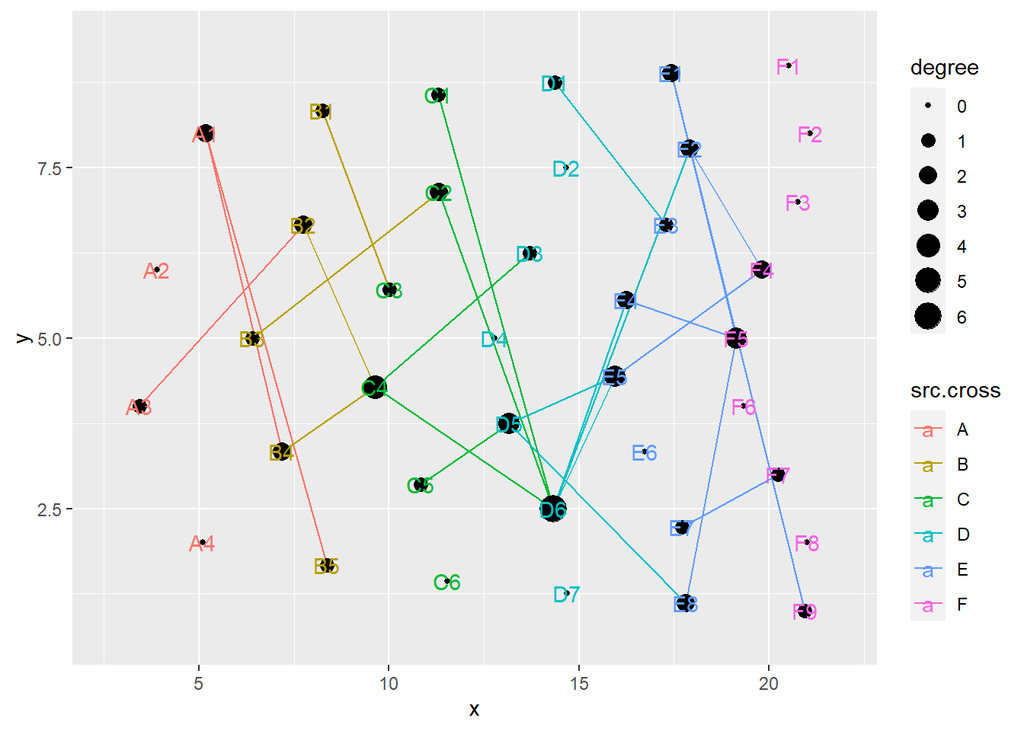

```r
# tf_fun, coordinate transformation according to custom-defined function
cl %>% tf_fun(fun = sin,along = "y",xrange.from=c(0,0.5*pi)) %>% cl_plot()
```

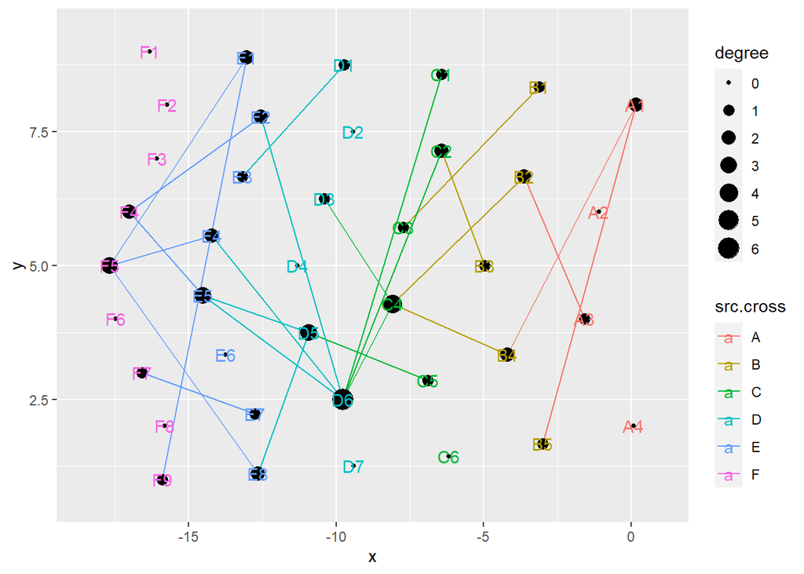

```r
# combined tf functions
cl %>% tf_flip(axis = "y") %>% tf_fun(fun = sin,along = "y",xrange.from=c(0,0.5*pi)) %>% cl_plot()
```

### 4). Layout modules

1. Commonly used styles are predefined in layout module, including row, column, arc, polygon and hive. crosses can be specified in all five layout module
2. ‘set_header’ function is provided to conveniently place cross headers

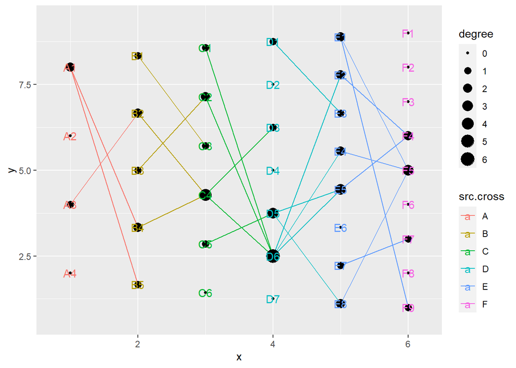

```r
# default layout module is column
cl %>% cl_plot()
```

```
## Copy layout default into default, and Set active layout to default
## Copy layout default into default, and Set active layout to default
```

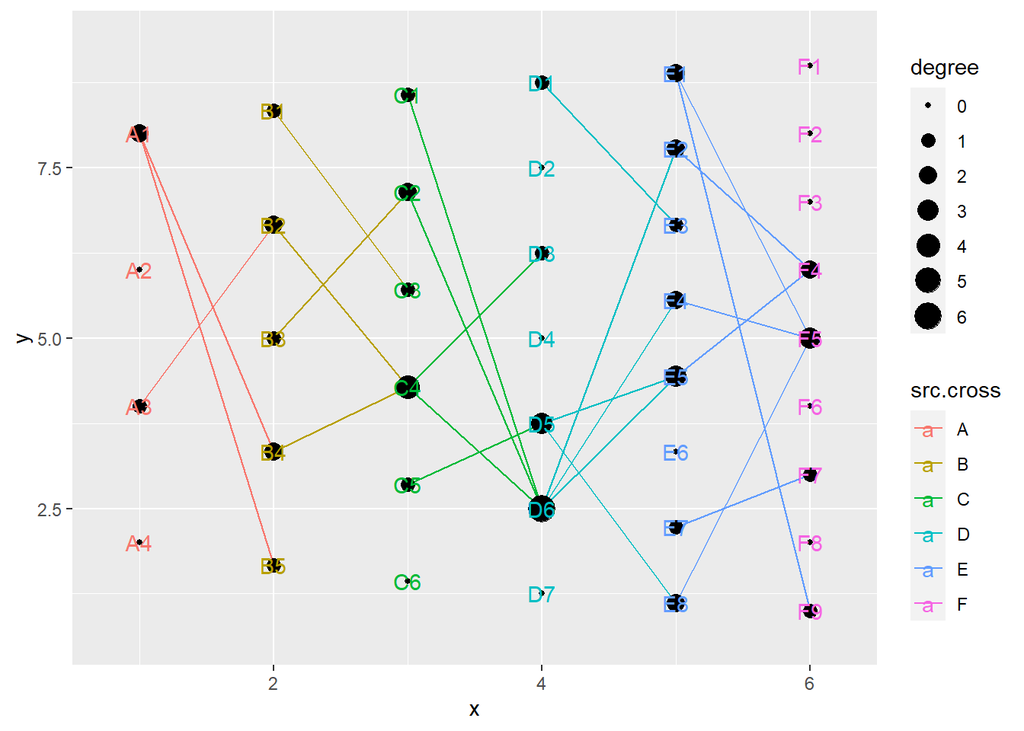

```r
cl %>% layout_column() %>% cl_plot()
```

```
## Copy layout default into default, and Set active layout to default
```

```
## Copy layout temp into default, and Set active layout to default
```

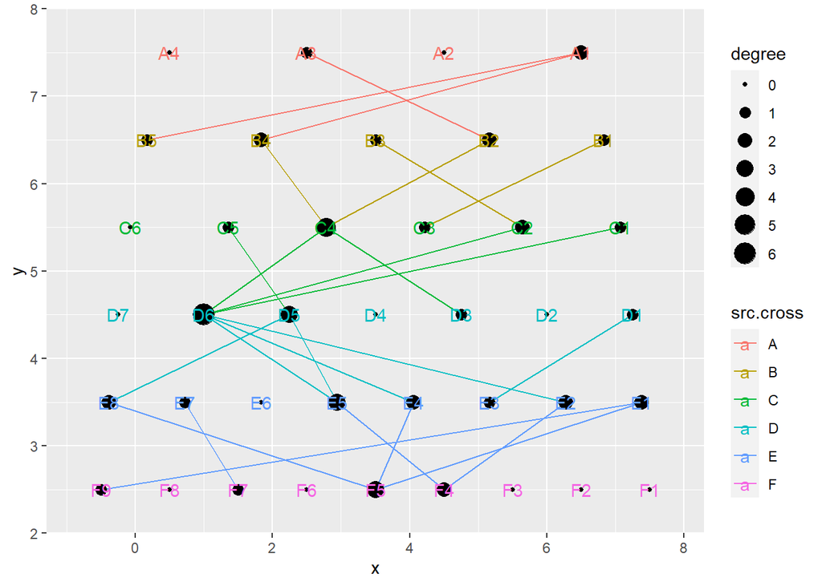

```r
# layout by row
cl %>% layout_row() %>% cl_plot()
```

```
## Copy layout default into temp, and Set active layout to temp
```

```
## Copy layout default into default, and Set active layout to default
```

```
## Copy layout temp into default, and Set active layout to default
```

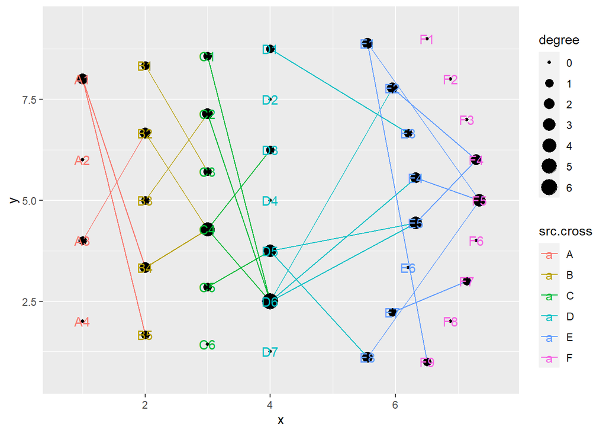

```r
# layout by arc
cl %>% layout_arc(angles = 60,crosses = c("E","F")) %>% cl_plot()
```

```
## Copy layout default into default, and Set active layout to default
## Copy layout temp into default, and Set active layout to default
```

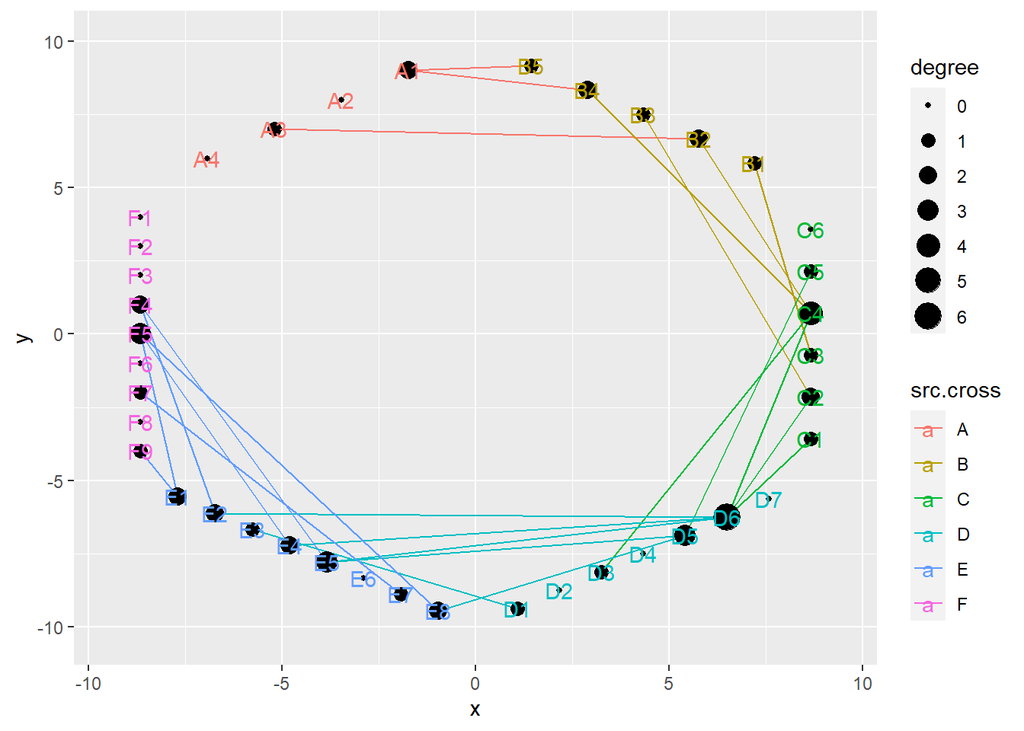

```r
# layout by polygon (list of angles must have the same length with crosses)
cl %>% layout_polygon() %>% cl_plot()
```

```
## Copy layout default into default, and Set active layout to default
## Copy layout temp into default, and Set active layout to default
```

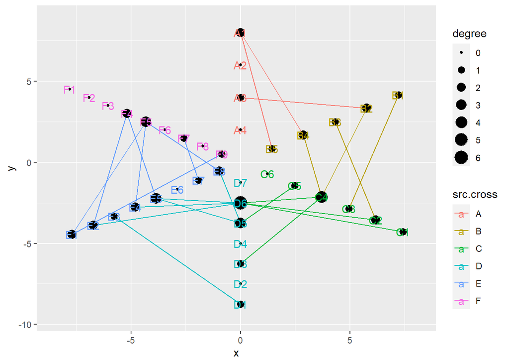

```r
# layout by hive
cl %>% layout_hive() %>% cl_plot()
```

```r
# Header can be customized through 'set_header'
set_header(cl,header = c("A","B","C","D","E","F")) -> cl
cl %>% get_header()  # get header of crosslink object
```

```
##       node node.type x   y cross header
## 1 A_HEADER    header 1 9.5     A      A
## 2 B_HEADER    header 2 9.5     B      B
## 3 C_HEADER    header 3 9.5     C      C
## 4 D_HEADER    header 4 9.5     D      D
## 5 E_HEADER    header 5 9.5     E      E
## 6 F_HEADER    header 6 9.5     F      F
```

### 5). Plotting modules

We introduce this pattern in three aspects.

1. quick plotting (`cl_plot`)
2. aesthetic settings ( The color, size, type and text of the nodes and lines in the network)
3. combination of the network diagram with the corresponding node annotation image in aligning coordinates

#### a. quick plotting

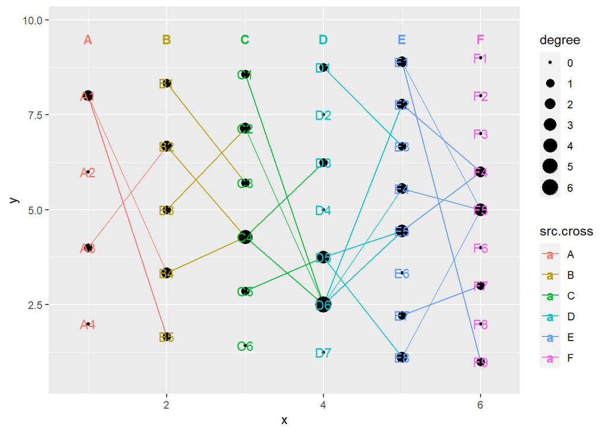

```r
cl %>% cl_plot()
```

#### b. aesthetic settings

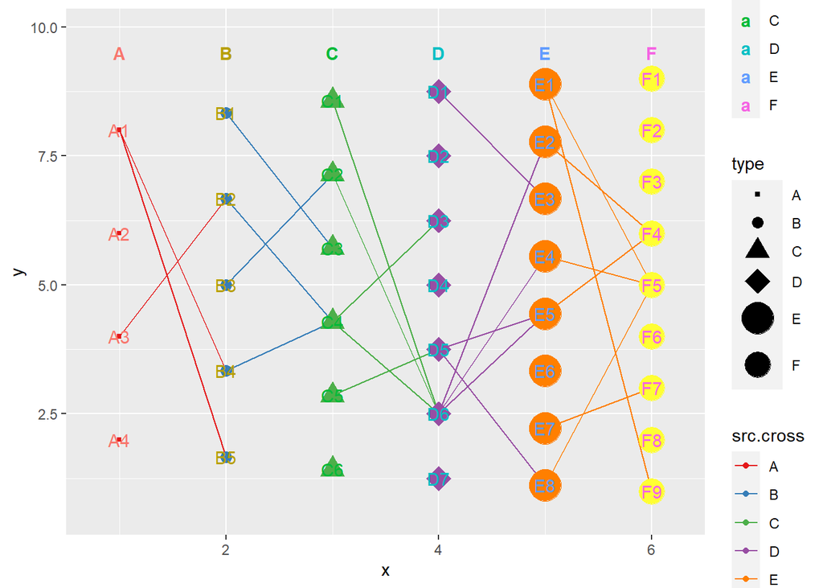

```r
# aesthetic settings based on ggplot2 system, some specific examples are shown below.

# set colors, shapes and size of nodes
# cross:a named list of arguments for crosses. usage same as ggplot2::geom_point(). Set NULL to use default settings, or Set NA to not show.
cl %>% cl_plot(cross = list(mapping =  aes(color = type,shape= type,size=type),
                            scale   = list(color = scale_color_manual(values = RColorBrewer::brewer.pal(8, "Set1")),
                                           size  = scale_size_manual(values = seq(1,12,by=2)),
                                           shape  = scale_shape_manual(values = c(15:22))
                                          )
                           ))
```

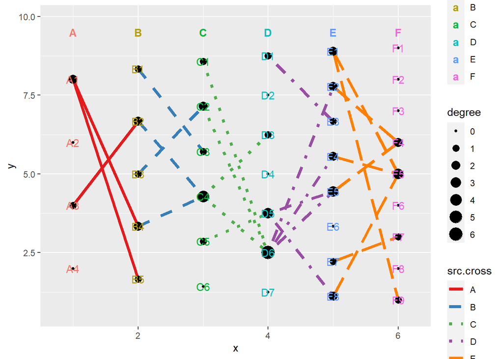

```r
# set colors, linetypes and size of edges
# link: a named list of arguments for links. usage same as ggplot2::geom_segment(). Set NULL to use default settings, or Set NA to not show.
cl %>% cl_plot( link = list(mapping =  aes(color = src.cross,linetype =src.cross),
                            scale   = list(color = scale_color_manual(values = RColorBrewer::brewer.pal(8, "Set1")),
                                           linetype =scale_linetype_manual(values = c(1:6))),
                            size    = 1.5
                           ))
```

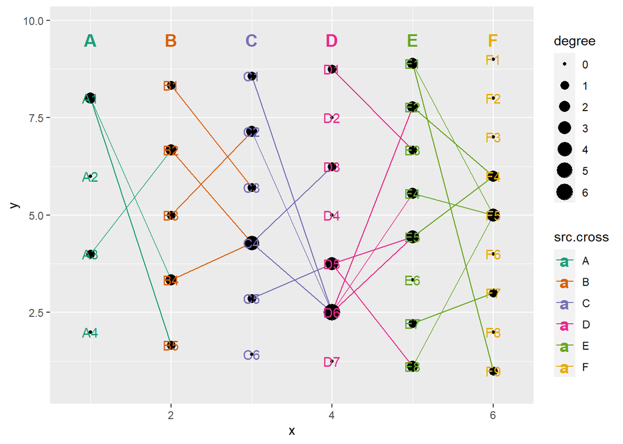

```r
# set header styles
# header:   a named list of arguments for headers. usage same as ggplot2::geom_text(). Set NULL to use default settings, or Set NA to not show.
cl %>% cl_plot(header = list(mapping = aes(color= cross),
                               scale = list(color = scale_color_manual(values = RColorBrewer::brewer.pal(8, "Dark2"))),
                                size = 5
                             ))
```

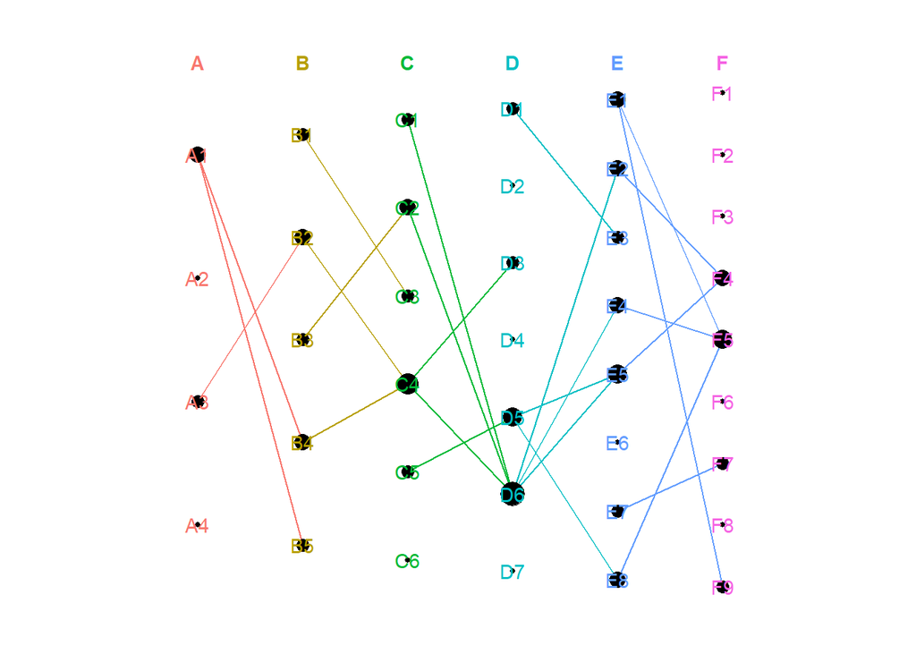

```r
# set figure theme
# add:  other gg object to be added to final plot, such as theme().
theme_use <- theme(legend.position = "none",aspect.ratio = 1,
                   axis.title = element_blank(),
                   axis.text = element_blank(),
                   axis.ticks = element_blank(),
                   panel.grid = element_blank(),
                   panel.background = element_blank())
cl %>% cl_plot(add=theme_use)
```

#### c. annotation figure

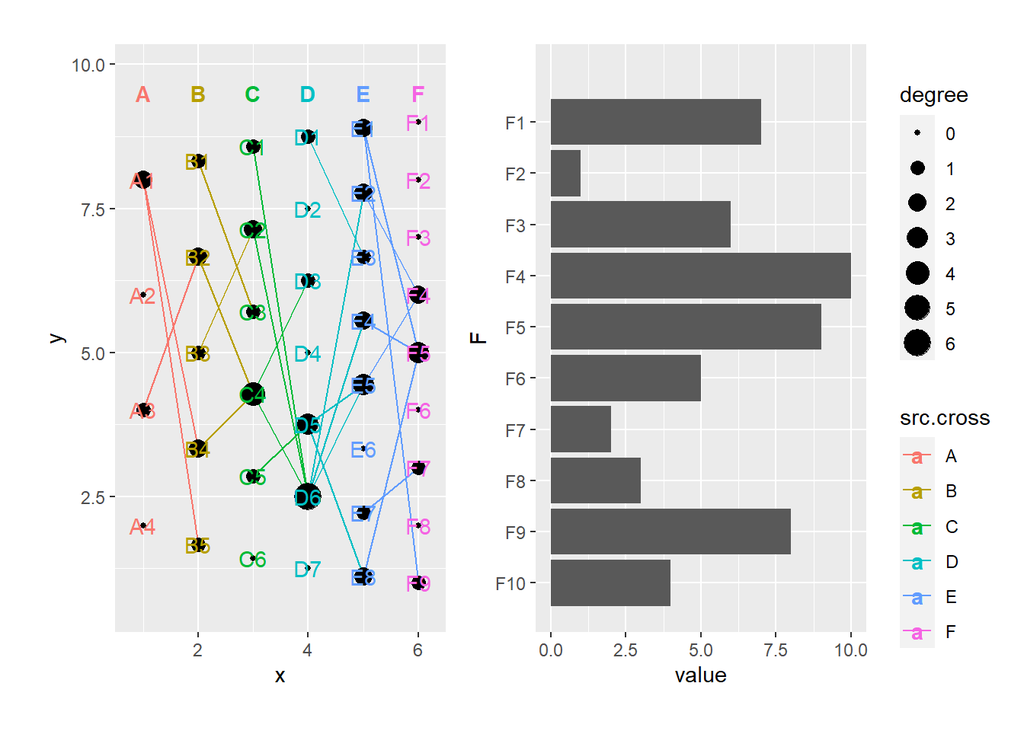

```r
# cl_annotation： add annotation figure.
# top, bottom, left or  right   : ggplot object
# top.by, bottom.by, left.by, right.by : name of cross by which to align ggplot

ann.data <- data.frame(F=factor(paste0("F",c(1:10)),levels=paste0("F",c(10:1))),value=sample(size = 10,x=c(1:10)))
ann.data %>% ggplot(mapping = aes(x=F,y=value))+geom_bar(stat="identity")+coord_flip() -> rgtAnn

cl %>% cl_plot(annotation=cl_annotation(right= rgtAnn,right.by ="F"))
```

## 4. Examples

There are examples used in paper and practical application.

### 1). examples used in paper

#### a. layout by row

```
## Copy layout default into default, and Set active layout to default
```

```
## Copy layout temp into default, and Set active layout to default
```

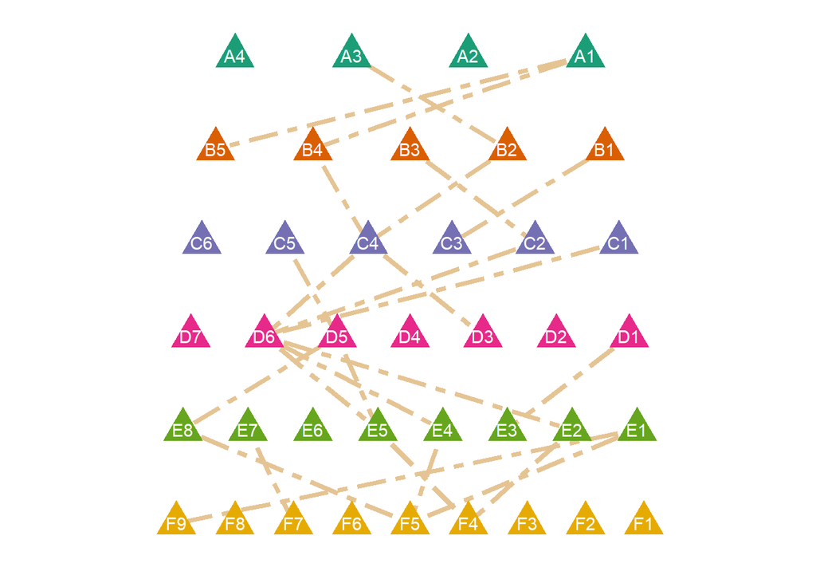

```r
cl <- crosslink(demo$nodes, demo$edges, demo$cross.by, odd.rm = F,spaces = "flank")

cl %>% layout_row() %>%
   cl_plot(cross = list(mapping = aes(color  = type,fill=type),
                        scale   = list(color = scale_color_manual(values = RColorBrewer::brewer.pal(8, "Dark2")),
                                        fill = scale_fill_manual( values = RColorBrewer::brewer.pal(8, "Dark2"))),
                        size=8,shape=24
                       ),
          link   = list(color=RColorBrewer::brewer.pal(8, "Set2")[7],size=1.5,linetype=12),
          label  = list(color="white"),
          header = list(mapping = aes(color= cross),
                        scale = list(color = scale_color_manual(values = RColorBrewer::brewer.pal(8, "Dark2"))),
                        size=5
                       ),
          add=theme_use)
```

#### b. layout by rotate

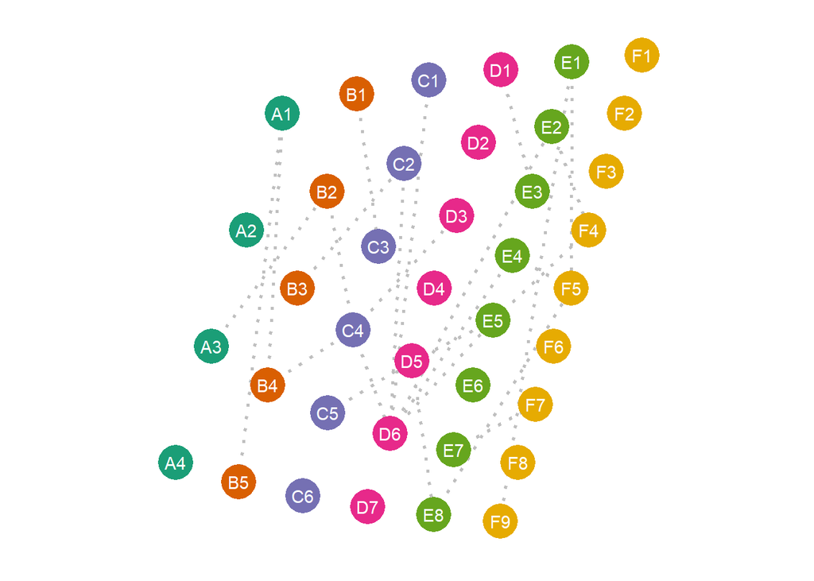

```r
cl %>%
   tf_rotate(angle = 15, by.each.cross = T) %>%
   cl_plot(cross = list(mapping = aes(color = type),
                       scale = list(color = scale_color_manual(values = RColorBrewer::brewer.pal(8, "Dark2"))),
                       size=10,shape=16
                       ),
          link = list(color="grey75",size=1,linetype=15),
          label = list(color="white"),
          header = list(mapping = aes(color= cross),
                       scale = list(color = scale_color_manual(values = RColorBrewer::brewer.pal(8, "Dark2"))),
                       size=5
                       ),
          add=theme_use)
```

#### c. layout by polygon

```
## Copy layout default into default, and Set active layout to default
```

```
## Copy layout temp into default, and Set active layout to default
```

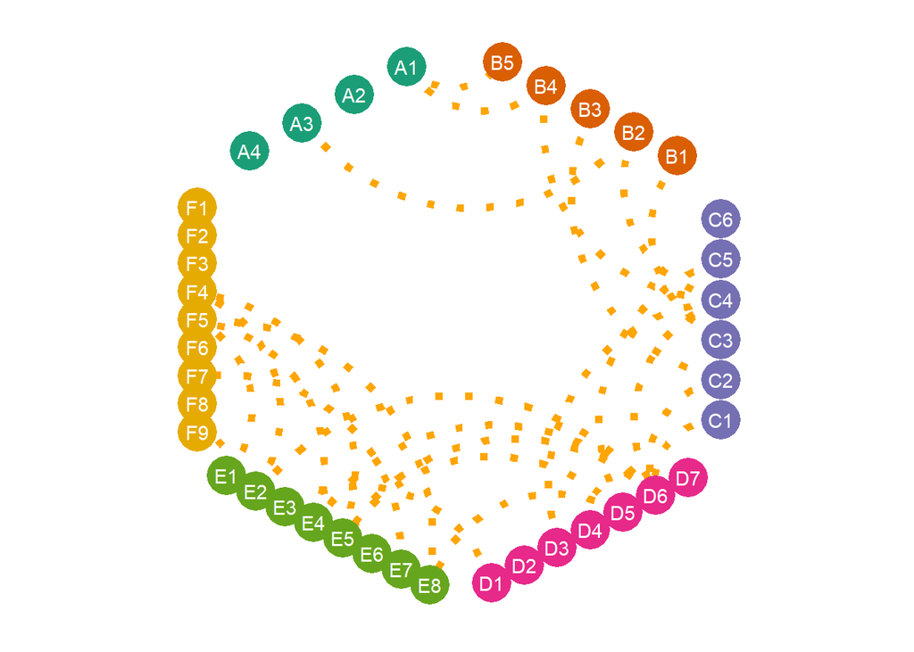

```r
cl %>% layout_polygon() %>%
   #tf_rotate(angle = 45, by.each.cross = F) %>%  # If the grouping is 4, rotate by this parameter and change from diamond to square
   cl_plot(cross = list(mapping = aes(color = type),
                        scale = list(color = scale_color_manual(values = RColorBrewer::brewer.pal(8, "Dark2"))),
                        size=10,shape=16
                       ),
           link  = list(color="orange",size=2,linetype=15,geom="curve"),
           label = list(color="white"),
           header= list(mapping = aes(color= cross),
                        scale = list(color = scale_color_manual(values = RColorBrewer::brewer.pal(8, "Dark2"))),
                        size=5
                        ),
           add  =  theme_use )
```

#### d. layout by hive

```
## Copy layout default into default, and Set active layout to default
```

```
## Copy layout temp into default, and Set active layout to default
```

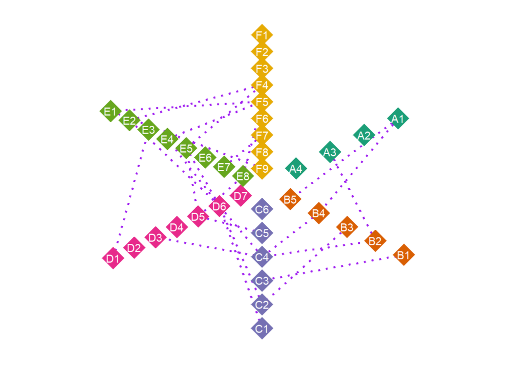

```r
cl %>% layout_hive(angles=rep(60,6)) %>% #length of angles must be same with the numbers of groups
       cl_plot(cross = list(mapping = aes(color = type),
                       scale = list(color = scale_color_manual(values = RColorBrewer::brewer.pal(8, "Dark2"))),
                       size=10,shape=18
                       ),
               link  = list(color="purple",size=1,linetype=15),
               label = list(color="white"),
               header= list(mapping = aes(color= cross),
                            scale = list(color = scale_color_manual(values = RColorBrewer::brewer.pal(8, "Dark2"))),
                            size=5
                            ),
               add   = theme_use )
```

#### e. layout by arc

```
## Copy layout default into temp, and Set active layout to temp
```

```
## Copy layout default into default, and Set active layout to default
```

```
## Copy layout temp into default, and Set active layout to default
```

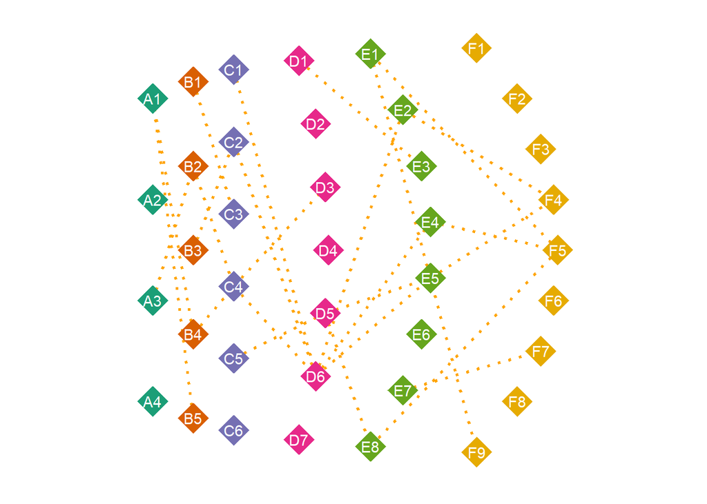

```r
cl %>% layout_arc(angles=c(60,120,180),crosses=c("D","E","F")) %>% #length of angles must be same with the numbers of crosses
       cl_plot(cross = list(mapping = aes(color = type),
                            scale = list(color = scale_color_manual(values = RColorBrewer::brewer.pal(8, "Dark2"))),
                            size=10,shape=18
                           ),
               link  = list(color="orange",size=1,linetype=3),#,geom="curve"
               label = list(color="white"),
               header= list(mapping = aes(color= cross),
                            scale = list(color = scale_color_manual(values = RColorBrewer::brewer.pal(8, "Dark2"))),
                            size=5
                           ),
               add   =  theme_use)
```

#### f. layout by combination of several methods

```r
# demo data
n <- 5
demo <- gen_demo(n_cross = n, n_node = rep(n, n), n_link = rep(n, n-1), seed = 66)
nodes <- demo$nodes
edges <- demo$edges
cross.by <- demo$cross.by


cl <- crosslink(nodes, edges, cross.by, odd.rm = F)
cl <- set_header(cl,header = c("A","B","C","D","E"))

cl %>%
   layout_polygon(crosses = c("A","B","C","D")) %>%
   tf_rotate(crosses=c("A","B","C","D"),angle = rep(45,4)) %>%
   tf_shift(x=0.8*(-1),y=0.05,crosses="E",layout="default") ->cl
```

```
## Copy layout default into default, and Set active layout to default
```

```
## Copy layout temp into default, and Set active layout to default
```

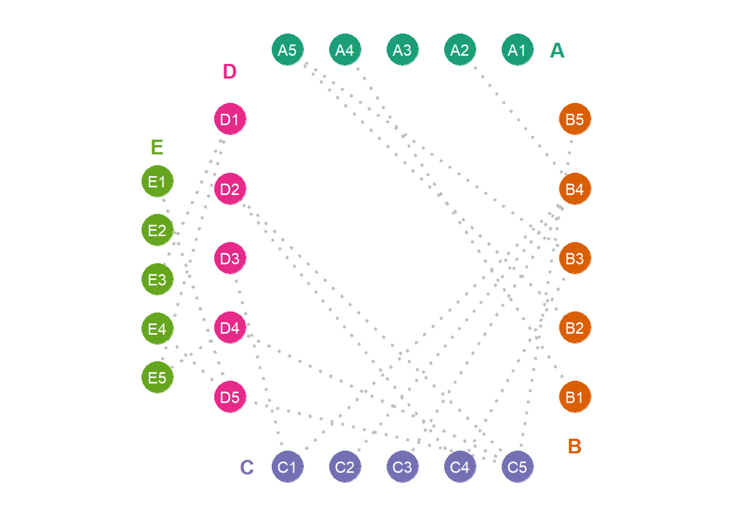

```r
cl %>%
   cl_plot(cross = list(mapping = aes(color = type),
                       scale = list(color = scale_color_manual(values = RColorBrewer::brewer.pal(8, "Dark2"))),
                       size=10,shape=19
                       ),
          link   = list(color="grey75",size=1,linetype=3),
          label  = list(color="white"),
          header = list(mapping = aes(color= cross),
                       scale = list(color = scale_color_manual(values = RColorBrewer::brewer.pal(8, "Dark2"))),
                       size=5
                       ),
           add   =  theme_use)
```

### 2). examples of complex figure

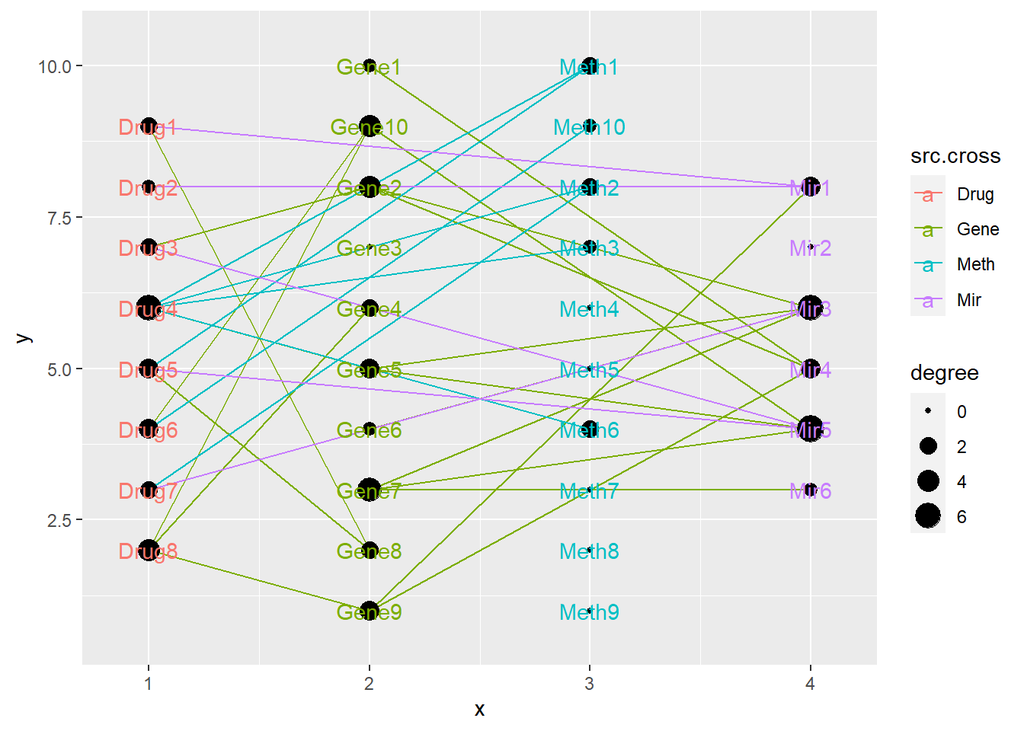

```r
library(dplyr)
library(reshape)
theme_classic() +
  theme(axis.text = element_blank(),
        axis.line.x = element_blank(),
        axis.ticks.x = element_blank()) ->theme_use2


## crosslink project
cl <- crosslink(example$nodes,example$edges,cross.by="type")

cl %>% cl_plot()
```

```r
cl <- set_header(cl,header=unique(get_cross(cl)$cross))

cl %>% layout_polygon(crosses = c("Mir","Meth","Gene","Drug"),layout_based = "default") %>%
       tf_rotate(crosses= c("Mir","Meth","Gene","Drug"),angle = rep(45,4),layout="default") %>%
       tf_shift(x=0.2*(-1),y=1.5,crosses=c("Mir","Meth"),layout="default") -> cl
```

```
## Copy layout default into default, and Set active layout to default
```

```
## Copy layout temp into default, and Set active layout to default
```

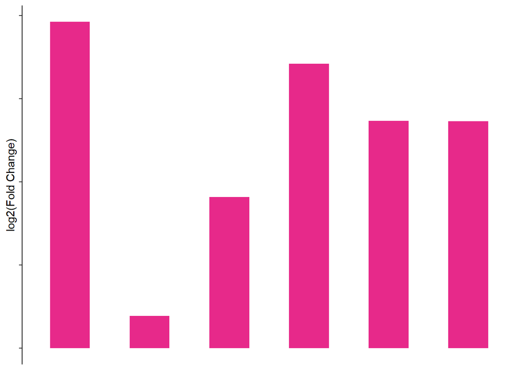

```r
# plot annotation
top <- nodes$id[nodes$type == "Mir"] # set the order as you like
bottom <- nodes$id[nodes$type == "Gene"] # set the order as you like
right <- nodes$id[nodes$type == "Meth"] # set the order as you like

# Top plot
topAnn <-  mirData %>%
  mutate(mir_f = factor(mir, top)) %>%
  ggplot(mapping = aes(x=mir,y=-lfc)) +
  geom_bar(fill = "#E7298A",
           stat = "identity",
           width = 0.5) +
  labs(x = NULL, y = "log2(Fold Change)") +
  theme_use2
topAnn
```

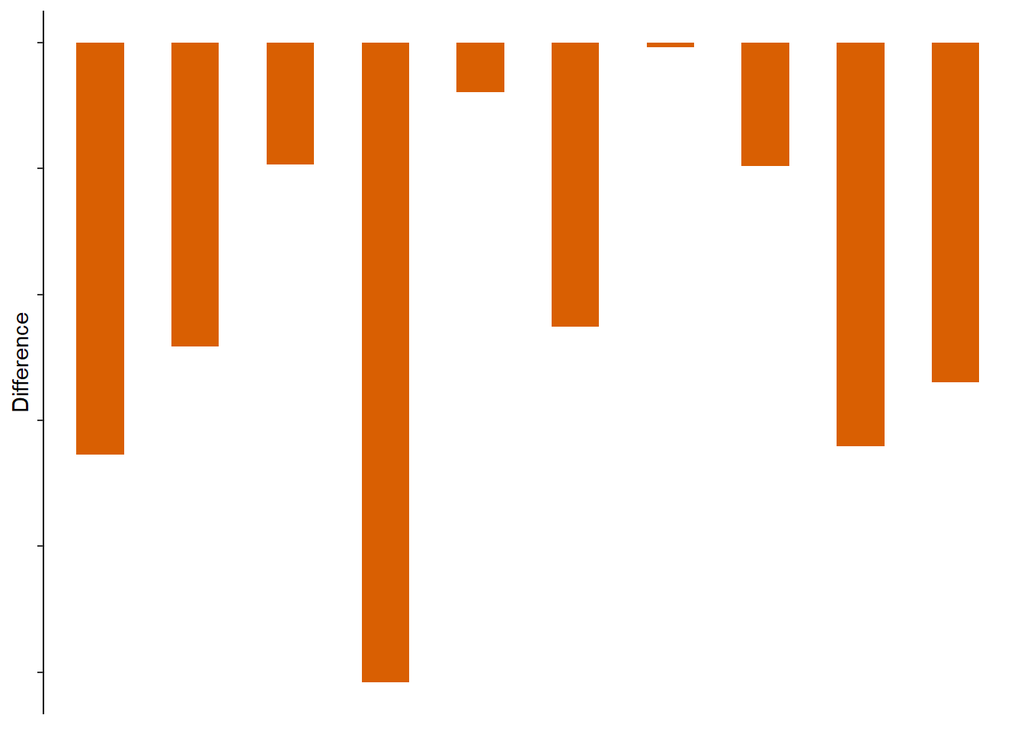

```r
# Bottom plot
botAnn <- geneData %>%
  mutate(meth_f = factor(gene, bottom)) %>%
  ggplot(mapping = aes(x=gene,y=-lfc)) +
  geom_bar(fill =  RColorBrewer::brewer.pal(8, "Dark2")[c(1:5,7:9)][2],
           stat = "identity",
           width = 0.5) +
  labs(x = NULL, y = "Difference") +
  theme_use2
botAnn
```

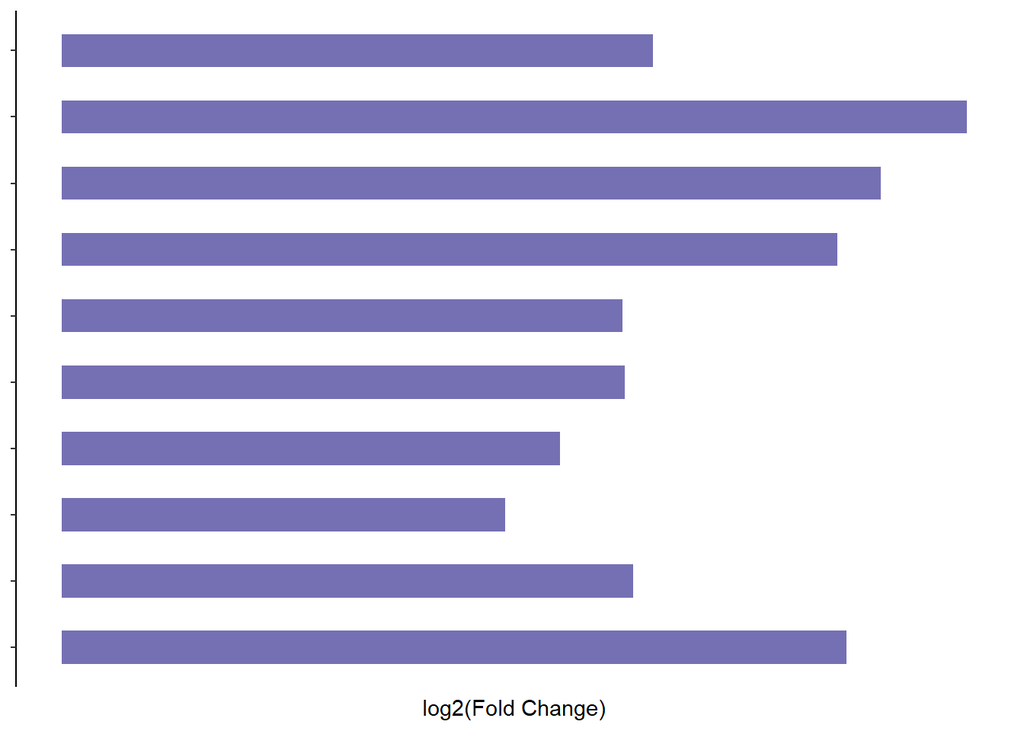

```r
# right plot
rgtAnn <- methData %>%
  mutate(mir_f = factor(meth, right)) %>%
  ggplot(mapping = aes(x=meth,y=-lfc)) +
  geom_bar(fill = RColorBrewer::brewer.pal(8, "Dark2")[c(1:5,7:9)][3],
           stat = "identity",
           width = 0.5) +
  labs(x = NULL, y = "log2(Fold Change)") +
  theme_use2 +
  coord_flip()

rgtAnn
```

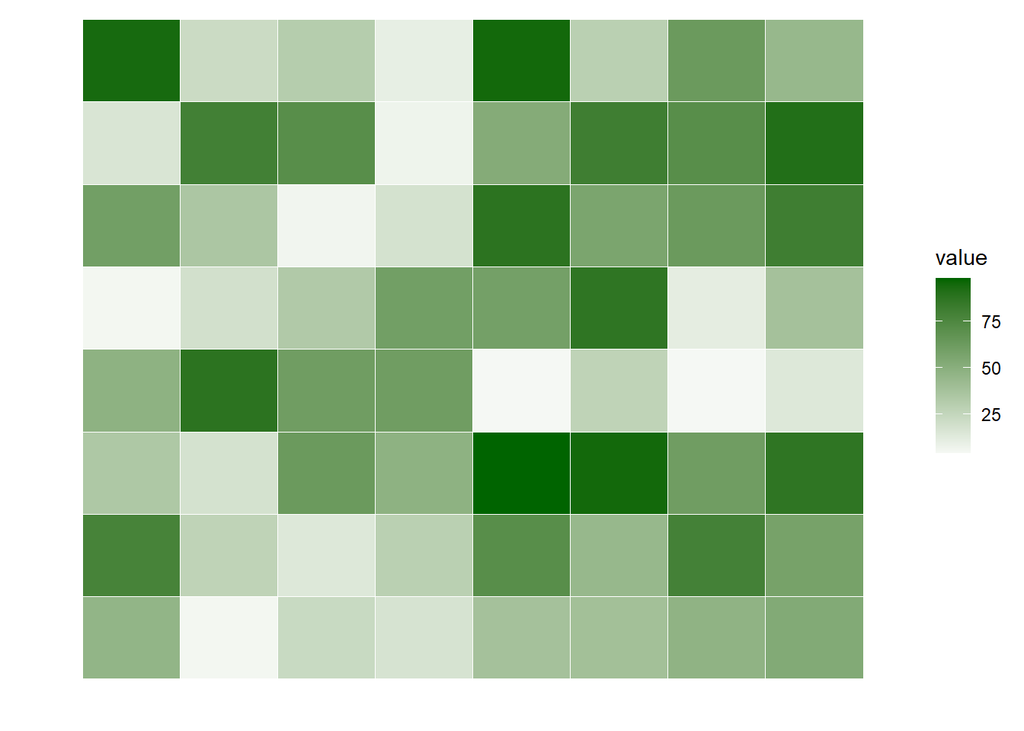

```r
# left plot
mat = matrix(sample(1:100, 64, replace = T), nrow = 8)
colnames(mat)=as.character(cl@cross$Drug)
ggplot(data = melt(mat), aes(X1, X2, fill = value))+
     geom_tile(color = "white")+
     scale_fill_gradient2(low = "blue", high = "darkgreen", mid = "white",midpoint = 0) +
     xlab("")+ylab("")+theme_classic()+
     theme(legend.position = "right",
          axis.line = element_blank(),
          axis.ticks = element_blank(),
           axis.text = element_blank()) -> lftAnno
lftAnno
```

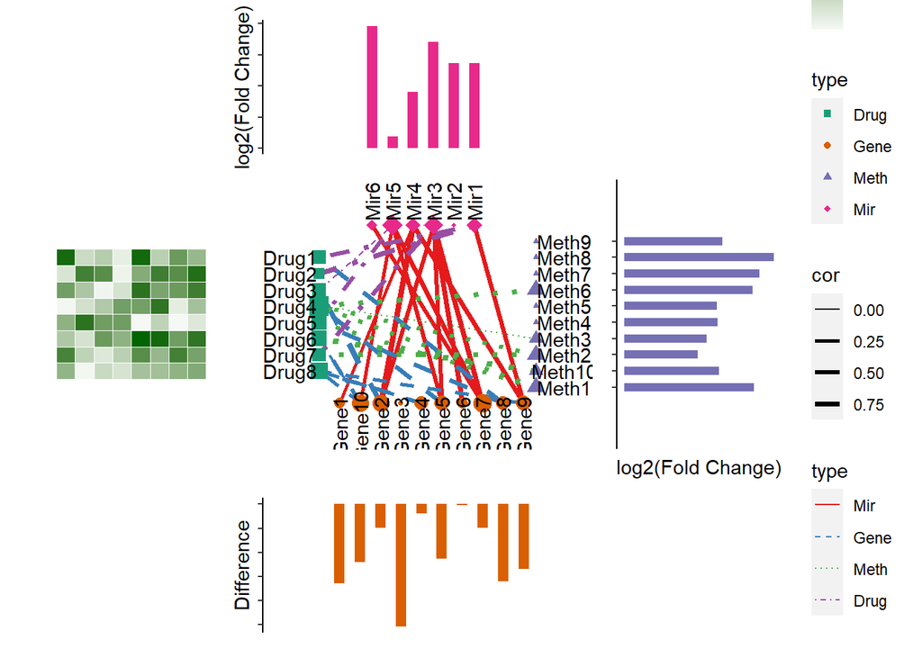

```r
cl_plot(cl,
       annotation=cl_annotation(top = topAnn,top.by = "Mir",top.height = 0.5,
                                bottom = botAnn,bottom.by = "Gene",bottom.height = 0.5,
                                right = rgtAnn,right.by ="Meth",right.width = 0.5,
                                left = lftAnno,left.by = "Drug" ,left.width = 0.5),
       cross = list( mapping = aes(color = type,size=degree,shape=type),
       scale = list(color = scale_color_manual(values = RColorBrewer::brewer.pal(8, "Dark2")[c(1:5,7:9)]),
       shape = scale_shape_manual(values = 15:23),
       size  = scale_size_continuous(range=c(1,5)))),
       link  = list(mapping = aes(color = type,linetype=type,size=cor),
                    scale = list(color = scale_color_manual(values = RColorBrewer::brewer.pal(8, "Set1")[c(1:5,7:9)]),
                                linetype=scale_linetype_manual(values = c(1:4)),
                                size=scale_size(range = c(0.5,1.5)))),
       header=NA,
       label = list(color="black"
                    ,angle=c(rep(0,8),rep(90,10),rep(0,10),rep(90,6))
                    ,nudge_x=c(rep(-2,8),rep(0,10),rep(2,10),rep(0,6))
                    ,nudge_y=c(rep(0,8),rep(-2,10),rep(0,10),rep(2,6))),
       add   =  theme(panel.background = element_blank(),axis.title = element_blank(),
                      panel.grid = element_blank(),
                      axis.ticks = element_blank(),
                      axis.text = element_blank()))
```